# MTH6139 Time Series

Coursework 1 – 220064853

Kawthar Tchakar

Spring term 2025

# Introduction

This project explores how many exoplanets have been discovered over the years, starting from 1992, using data of confirmed exoplanets from NASA’s Exoplanet Archive. The goal of this project is to implement Meta’s Prophet forecasting system to model the number of exoplanets discovered per year and forecast the potential number of discoveries in the future.

# Data

From [NASA Exoplanet Archive](https://exoplanetarchive.ipac.caltech.edu), I downloaded [Planetary Systems Composite Data](https://exoplanetarchive.ipac.caltech.edu/cgi-bin/TblView/nph-tblView?app=ExoTbls&config=PSCompPars). The non composite data available on the website contained one row per planet per reference creating multiple parameters, whereas the composite data has one row per planet combining the parameters from different papers. I installed Prophet using ‘install.packages(“prophet”)’ and ‘remotes::install_github’. There were no major differences observed between these two.

```r
library(prophet)

#Load the confirmed exoplanet data
#comment.char = "#" removes the header comments in NASA's data
exoplanet_data <- read.csv(file.path("data", "PSComp.csv"), comment.char = "#")

#Select the relevant columns:planet name, discovery year, discovery method and discovery facility
exoplanet_data <- exoplanet_data[, c("pl_name", "disc_year", "discoverymethod", "disc_facility")]

#Exploring the first 6 rows of data
head(exoplanet_data)
```

```
##      pl_name disc_year discoverymethod                          disc_facility
## 1   11 Com b      2007 Radial Velocity                       Xinglong Station
## 2   11 UMi b      2009 Radial Velocity Thueringer Landessternwarte Tautenburg
## 3   14 And b      2008 Radial Velocity      Okayama Astrophysical Observatory
## 4   14 Her b      2002 Radial Velocity                 W. M. Keck Observatory
## 5 16 Cyg B b      1996 Radial Velocity                 Multiple Observatories
## 6   17 Sco b      2020 Radial Velocity                       Lick Observatory
```

```r
#Find how many rows of exoplanets there are
nrow(exoplanet_data)
```

```
## [1] 6150
```

```r
#Range shows the first and most recent year of discovery
range(exoplanet_data$disc_year, na.rm = TRUE)
```

```
## [1] 1992 2026
```

The dataset contains 6150 confirmed exoplanets that were discovered from 1992 to 2026.

# Exploration

```r
#Discovery count per year
discoveries_per_year <- as.data.frame(table(exoplanet_data$disc_year))
colnames(discoveries_per_year) <- c("Year", "Count")

#Check for exoplanets with missing discovery years
exoplanet_data[is.na(exoplanet_data$disc_year),]
```

```
##         pl_name disc_year discoverymethod
## 5732 TOI-5789 c        NA         Transit
##                                     disc_facility
## 5732 Transiting Exoplanet Survey Satellite (TESS)
```

```r
#Found one, let's remove this row
discoveries_per_year <- na.omit(discoveries_per_year)
```

Only one exoplanet, TOI-5789 c, in row 5732, has a missing discovery year.

```r
head(discoveries_per_year, 15)
```

```
##    Year Count
## 1  1992     2
## 2  1994     1
## 3  1995     1
## 4  1996     6
## 5  1997     1
## 6  1998     6
## 7  1999    13
## 8  2000    16
## 9  2001    12
## 10 2002    29
## 11 2003    22
## 12 2004    27
## 13 2005    36
## 14 2006    32
## 15 2007    52
```

The table shows the number of confirmed exoplanets discovered in the first 15 years. Discoveries were slow at the start before picking up in 1996.

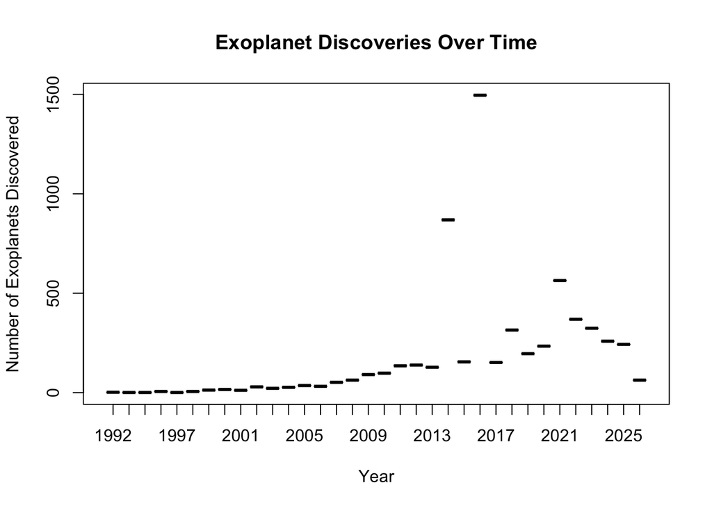

```r
#Plot graph showing the discoveries over time
plot(discoveries_per_year$Year, discoveries_per_year$Count,
     type = "o", col = "violetred",
     xlab = "Year",
     ylab = "Number of Exoplanets Discovered",
     main = "Exoplanet Discoveries Over Time")
```

The plot shows a positive trend in exoplanets discovered over time, with a sudden spike in 2014-2016 before dropping back down, but continues to increase at a higher rate than pre 2014. Due to the scale of the y-axis, it may look like no discoveries were made in the earlier years, however, from the previous table, we know that a small number of exoplanets were in fact discovered.

# Linear regression

```r
#Convert Year to numeric for regression
discoveries_per_year$YearNumber <- as.numeric(as.character(discoveries_per_year$Year))

#Fit linear regression
exoplanet_lm <- lm(Count ~ YearNumber, data = discoveries_per_year)
summary(exoplanet_lm)
```

```
##
## Call:
## lm(formula = Count ~ YearNumber, data = discoveries_per_year)
##
## Residuals:
##     Min      1Q  Median      3Q     Max
## -348.88  -96.55  -67.82    8.38 1223.89
##
## Coefficients:
##               Estimate Std. Error t value Pr(>|t|)
## (Intercept) -27905.404   9261.552  -3.013  0.00502 **
## YearNumber      13.977      4.609   3.033  0.00478 **
## ---
## Signif. codes:  0 '***' 0.001 '**' 0.01 '*' 0.05 '.' 0.1 ' ' 1
##
## Residual standard error: 265 on 32 degrees of freedom
## Multiple R-squared:  0.2232, Adjusted R-squared:  0.199
## F-statistic: 9.197 on 1 and 32 DF,  p-value: 0.004779
```

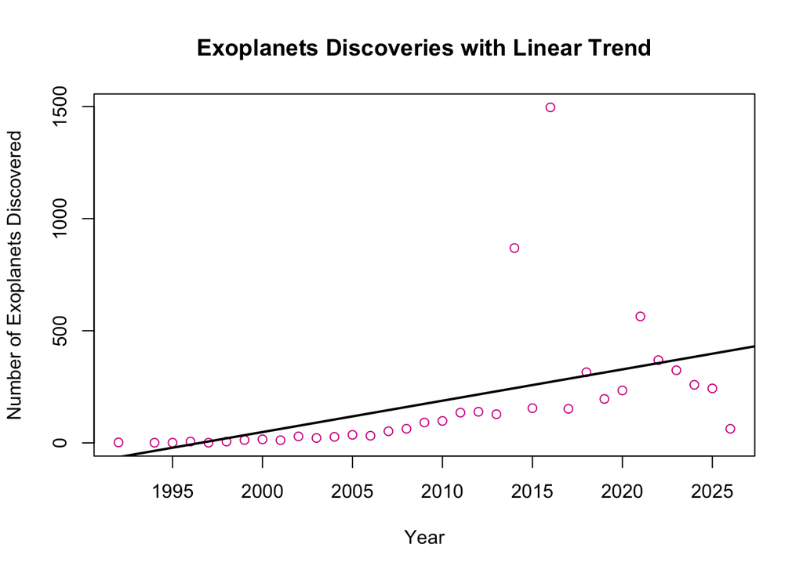

```r
#Plot with regression line
plot(discoveries_per_year$YearNumber, discoveries_per_year$Count,
     col = "violetred",
     xlab = "Year",
     ylab = "Number of Exoplanets Discovered",
     main = "Exoplanets Discoveries with Linear Trend")
abline(exoplanet_lm, col = "black", lwd = 2)
```

The line of best fit indicates a positive linear relationship between the year and the number of discoveries. However, it seems to ignore the decrease in discoveries made post 2016, suggesting the linear regression model might not be sufficient enough in describing the data. We will use Prophet to model this complex pattern.

# Prophet Forecast

Prophet is a forecasting tool that works by decomposing a time series into trend and seasonality components and then predicting future values.

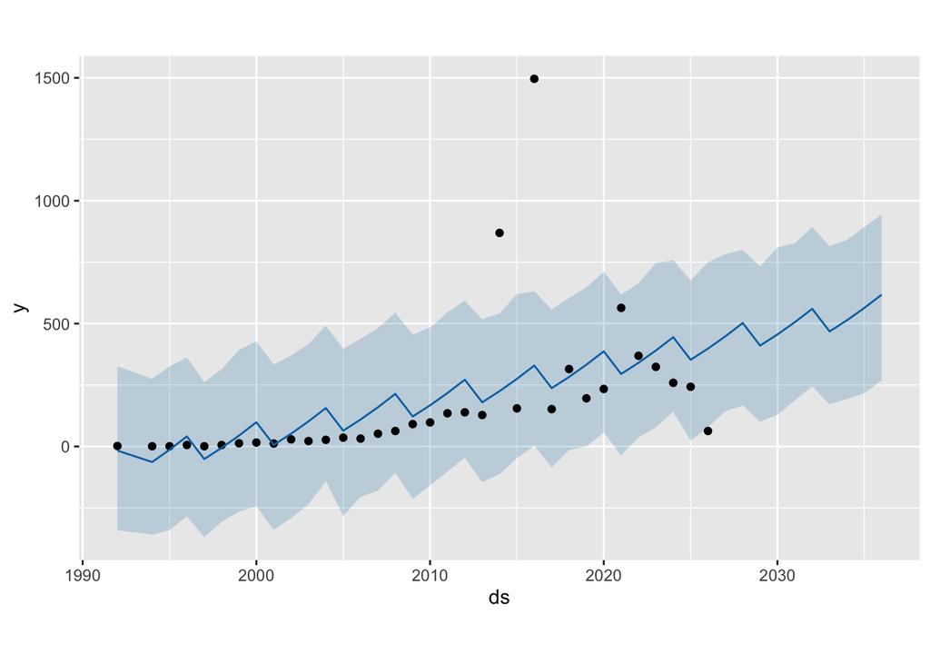

```r
#Converting dataframe to Prophet format
#Columns: ds = date, y = value
exoplanet_prophet <- data.frame(
    ds = as.Date(paste0(discoveries_per_year$Year, "-01-01")),
    y = discoveries_per_year$Count
)

#Fit model
exoplanet_model <- prophet(exoplanet_prophet)

#Forecast the next 10 years
future_dates <- make_future_dataframe(exoplanet_model, periods = 10, freq = "year")
exoplanet_forecast <- predict(exoplanet_model, future_dates)

#Plot forecast
plot(exoplanet_model, exoplanet_forecast)
```

The black dots represent the total number of discoveries made in the year, the blue line represents Prophet’s forecast and the shaded light blue area represents the upper and lower range predictions of uncertainty. Here, the forecast is set to predict the next 10 years where it shows an increase in the discovery of more exoplanets despite the decline in the number of discoveries made after 2021.

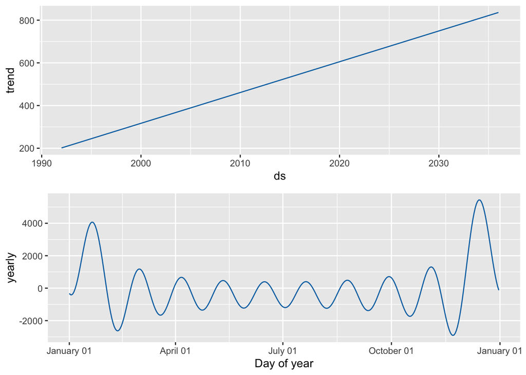

```r
#Plotting components
prophet_plot_components(exoplanet_model, exoplanet_forecast)
```

The trend graph shows a steady increase of discoveries over the years and the yearly graph shows a seasonal pattern within each year even though the data is recorded annually, due to this, further analysis would be required to fully interpret the data.

# Forecast values

```r
#Produce the predicted values for the next 10 years from 2026
#ds = date, yhat = Prophet's prediction for number of discoveries that year, yhat_lower = lowest possible prediction, yhat_upper = highest possible prediction
exoplanet_forecast[exoplanet_forecast$ds >= "2026-01-01", c("ds", "yhat", "yhat_lower", "yhat_upper")]
```

```
##            ds     yhat yhat_lower yhat_upper
## 34 2026-01-01 398.2367   78.85546   749.6063
## 35 2027-01-01 448.1415  143.29201   783.3994
## 36 2028-01-01 502.4285  166.47951   799.7585
## 37 2029-01-01 410.4454  100.56844   733.0800
## 38 2030-01-01 455.9257  129.22179   810.4877
## 39 2031-01-01 505.8305  187.05674   826.8255
## 40 2032-01-01 560.1175  244.28378   892.9667
## 41 2033-01-01 468.1344  171.69453   814.7090
## 42 2034-01-01 513.6147  192.79410   841.0362
## 43 2035-01-01 563.5195  216.49243   892.7229
## 44 2036-01-01 617.8064  268.94833   944.1181
```

The table shows Prophet’s predictions for the number of discoveries of exoplanets each year from 2026 to 2036. Looking at the columns, ‘yhat’ is Prophet’s best estimate, and ‘yhat_lower’ and ‘yhat_upper’ are the ranges of uncertainty for predictions. For example, in 2030, Prophet predicts that approximately 456 exoplanets will be discovered, but the real number of discoveries can be anywhere between the corresponding ‘yhat_lower’ and ‘yhat_upper’ values.

# Conclusion

This project used Prophet to forecast the number of exoplanet discoveries all the way up to 2036, with data showing significant growth since the first exoplanet discovered in 1992. But more testing would need to be done to clarify results.

# References

- NASA Exoplanet Archive: https://exoplanetarchive.ipac.caltech.edu
- Datacamp course: https://www.datacamp.com/courses/reporting-with-rmarkdown
- RStudio reference: https://rmarkdown.rstudio.com/lesson-1.html
- More sophisticated reference: https://bookdown.org/yihui/rmarkdown/
- Prophet documentation: https://facebook.github.io/prophet/docs/quick_start.html